# 431 Class 18

Thomas E. Love, Ph.D.

2025-11-04

## Today’s Agenda

Two-Factor (Two-Way) Analysis of Variance

- The importance of interaction
- Interpreting ANOVA output
- What are the key model checks for ANOVA?
- Comparing Model Performance Indices
- What if we add a covariate?

## R Packages

```r
library(janitor)
library(readxl)
library(gt)
library(easystats)
library(tidyverse)

source("c18/data/Love-431.R")
knitr::opts_chunk$set(comment = NA)

theme_set(theme_bw())
```

## The dm464 data, in full

We’ve discussed subsets of these data in previous classes.

```r
dm464 <- read_xlsx("c18/data/dm464.xlsx") |>
  janitor::clean_names() |>
  mutate(across(where(is.character), as_factor)) |>
  mutate(id_code = as.character(id_code),
         smoke_start = fct_relevel(smoke_start, "Current", "Former"),
         smoke_end = fct_relevel(smoke_end, "Current", "Former"),
         insur_start = fct_relevel(insur_start, "Medicare",
                                   "Commercial", "Medicaid"),
         insur_end = fct_relevel(insur_end, "Medicare",
                                   "Commercial", "Medicaid"))

dim(dm464)
```

```
[1] 464  42
```

## Descriptions for Today’s Variables

- Cohort of 464 English-speaking adults with diabetes measured at the start and end of a two-year period.

| Variable | Description |
| --- | --- |
| `id_code` | DM-xxxx code to identify subjects (not consecutive) |
| `bmi_end` | Body Mass Index in $(kg/m^2)$ at the end of the period |
| `dep_start` | Depression diagnosis at the start of the period (1 = yes, 0 = no) |
| `ed_start` | High = more than 78% of adult residents of subject’s home neighborhood graduated high school, vs. Low = no more than 78%. |
| `insur_start` | Subject’s insurance status at the start (3 levels) |

- 78% was close to the median value of the quantitative measure of high school graduation rate among enrolled subjects at the start of the period.
- All subjects have either Medicare, Commercial or Medicaid insurance.

## Today’s Variables

```r
dm18 <- dm464 |>
  mutate(ed_start = factor(ifelse(nedlev_start > 78, "High", "Low")),
         dep_start = factor(depdiag_start)) |>
  select(id_code, bmi_end, dep_start, ed_start, insur_start)

dm18 |> gt_preview()
```

|  | id_code | bmi_end | dep_start | ed_start | insur_start |
| --- | --- | --- | --- | --- | --- |
| 1 | DM-1007 | 47.2 | 0 | Low | Medicare |
| 2 | DM-1017 | 34.7 | 0 | High | Commercial |
| 3 | DM-1039 | 50.0 | 1 | High | Medicare |
| 4 | DM-1049 | 57.2 | 1 | Low | Medicaid |
| 5 | DM-1064 | 45.2 | 1 | Low | Medicaid |
| 6..463 |  |  |  |  |  |
| 464 | DM-9938 | 43.6 | 1 | High | Medicare |

## `data_codebook()` results

```r
data_codebook(dm18 |> select (-id_code))
```

```
select(dm18, -id_code) (464 rows and 4 variables, 4 shown)

ID | Name        | Type        | Missings |     Values |           N
---+-------------+-------------+----------+------------+------------
1  | bmi_end     | numeric     | 0 (0.0%) | [16, 78.3] |         464
---+-------------+-------------+----------+------------+------------
2  | dep_start   | categorical | 0 (0.0%) |          0 | 295 (63.6%)
   |             |             |          |          1 | 169 (36.4%)
---+-------------+-------------+----------+------------+------------
3  | ed_start    | categorical | 0 (0.0%) |       High | 228 (49.1%)
   |             |             |          |        Low | 236 (50.9%)
---+-------------+-------------+----------+------------+------------
4  | insur_start | categorical | 0 (0.0%) |   Medicare | 193 (41.6%)
   |             |             |          | Commercial |  61 (13.1%)
   |             |             |          |   Medicaid | 210 (45.3%)
--------------------------------------------------------------------
```

# Two-Factor Analysis of Variance: Example 1

## Example 1

Suppose we want to simultaneously understand the impacts of two factors on BMI at the end of the period, specifically:

- `dep_start` (1 or 0), and
- `ed_start` (Low or High)

and it is possible that the impact of depression diagnosis on BMI may depend on the home neighborhood’s educational attainment, and vice versa (i.e. depression and education may **interact**.)

## An interaction plot is a plot of means.

Calculate and store the group means.

```r
ex1_means <- dm18 |>
  group_by(dep_start, ed_start) |>
  summarize(mean_bmi = mean(bmi_end))

ex1_means
```

```
# A tibble: 4 × 3
# Groups:   dep_start [2]
  dep_start ed_start mean_bmi
  <fct>     <fct>       <dbl>
1 0         High         33.4
2 0         Low          34.1
3 1         High         35.7
4 1         Low          38.7
```

## How strong is the interaction?

Now, we’ll plot these means, and look for a substantial interaction (non-parallel lines.)

```r
ggplot(ex1_means, aes(x = dep_start, y = mean_bmi)) +
  geom_line(aes(group = ed_start, color = ed_start)) +
  geom_point(aes(color = ed_start)) +
  scale_color_material() +
  labs(title = "Example 1 Interaction Plot",
       subtitle = "Do we see substantially non-parallel lines?",
       y = "Mean BMI at end of period",
       x = "Depression Diagnosis (1 = yes, 0 = no)",
       color = "HS Graduation Rate")
```

## How strong is the interaction?

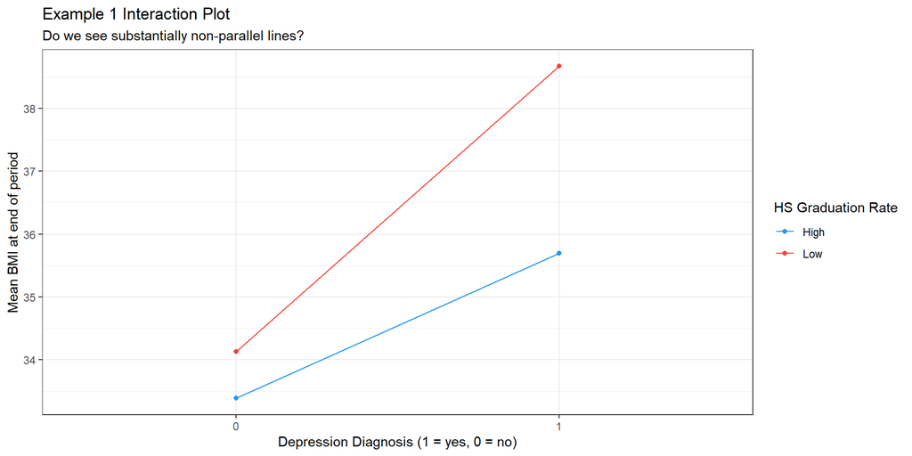

## Two-Way ANOVA without interaction

This model predicts our outcome (`bmi_end`) using the two factors as main effects only (with no interaction.)

```r
mainfx <- lm(bmi_end ~ dep_start + ed_start, data = dm18)

mainfx
```

```
Call:
lm(formula = bmi_end ~ dep_start + ed_start, data = dm18)

Coefficients:
(Intercept)   dep_start1  ed_startLow
     32.981        3.452        1.555
```

$$bmi_{end} = 32.98 + 3.452 (dep_{start} = 1) + 1.555 (ed_{start} = Low)$$

## Interpret the estimate: 3.45?

```r
model_parameters(mainfx, ci = 0.90, pretty_names = FALSE)
```

```
Parameter   | Coefficient |   SE |         90% CI | t(461) |      p
-------------------------------------------------------------------
(Intercept) |       32.98 | 0.65 | [31.91, 34.05] |  50.68 | < .001
dep_start1  |        3.45 | 0.84 | [ 2.06,  4.84] |   4.10 | < .001
ed_startLow |        1.56 | 0.81 | [ 0.22,  2.89] |   1.92 | 0.056
```

If we have two subjects who live in neighborhoods with the same `ed_start` value, but only one has a depression diagnosis at the start of the period, then **on average** the subject with a depression diagnosis will have a BMI that is 3.45 $kg/m^2$ higher than the subject without such a diagnosis, according to our `mainfx` model.

## Interpret the estimate: 1.56?

```r
model_parameters(mainfx, ci = 0.90, pretty_names = FALSE)
```

```
Parameter   | Coefficient |   SE |         90% CI | t(461) |      p
-------------------------------------------------------------------
(Intercept) |       32.98 | 0.65 | [31.91, 34.05] |  50.68 | < .001
dep_start1  |        3.45 | 0.84 | [ 2.06,  4.84] |   4.10 | < .001
ed_startLow |        1.56 | 0.81 | [ 0.22,  2.89] |   1.92 | 0.056
```

Our `mainfx` model estimates that if we have two subjects who have the same depression diagnosis status at the start of the period, but live in neighborhoods with different `ed_start` values (one High and one Low), then **on average** the subject living in the Low education neighborhood will have a BMI that is 1.56 $kg/m^2$ higher than the other subject.

## Interpret the intercept term?

```r
model_parameters(mainfx, ci = 0.90, pretty_names = FALSE)
```

```
Parameter   | Coefficient |   SE |         90% CI | t(461) |      p
-------------------------------------------------------------------
(Intercept) |       32.98 | 0.65 | [31.91, 34.05] |  50.68 | < .001
dep_start1  |        3.45 | 0.84 | [ 2.06,  4.84] |   4.10 | < .001
ed_startLow |        1.56 | 0.81 | [ 0.22,  2.89] |   1.92 | 0.056
```

32.98 is the intercept. It’s the `mainfx` model’s estimate of the mean of `bmi_end` across all subjects where both `dep_start` is 0 and `ed_start` = High.

## ANOVA table for main effects model

```r
anova(mainfx)
```

```
Analysis of Variance Table

Response: bmi_end
           Df Sum Sq Mean Sq F value   Pr(>F)
dep_start   1   1303 1302.59 17.1020 4.21e-05 ***
ed_start    1    280  280.48  3.6824  0.05561 .
Residuals 461  35113   76.17
---
Signif. codes:  0 '***' 0.001 '**' 0.01 '*' 0.05 '.' 0.1 ' ' 1
```

### % of Total SS explained by the two factors?

- Total SS = 1303 + 280 + 35113 = 36696
- So % explained = (1303 + 280) / 36696 = 0.043, or 4.3%

## Model `mainfx` and its assumptions

- `mainfx` is a “main effects only” model. It assumes there is zero interaction between `dep_start` and `ed_start` in predicting our outcome, `bmi_end`.
- Like any ANOVA model, `mainfx` makes the usual linear model assumptions (linearity, constant variance, Normality)
  - Focus: posterior predictive check, and Normal Q-Q plot of residuals<sup>1</sup>.
[^1]: The assessment of linearity and non-constant variance used by `check_model()` are best used when we have at least one quantitative predictor in our model.

## Checking model `mainfx`

```r
set.seed(20251104)
check_model(mainfx, check = c("pp_check", "qq"), detrend = FALSE)
```

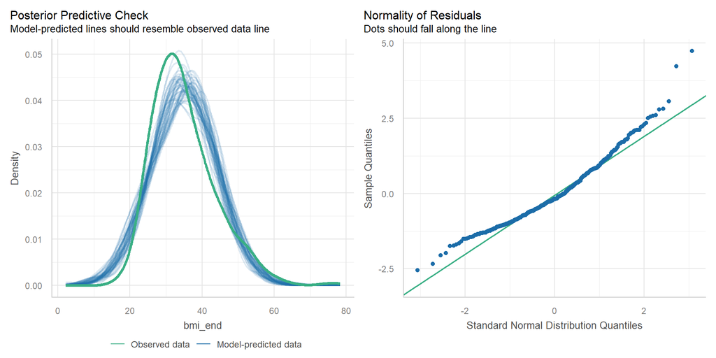

## Interaction Plot, again

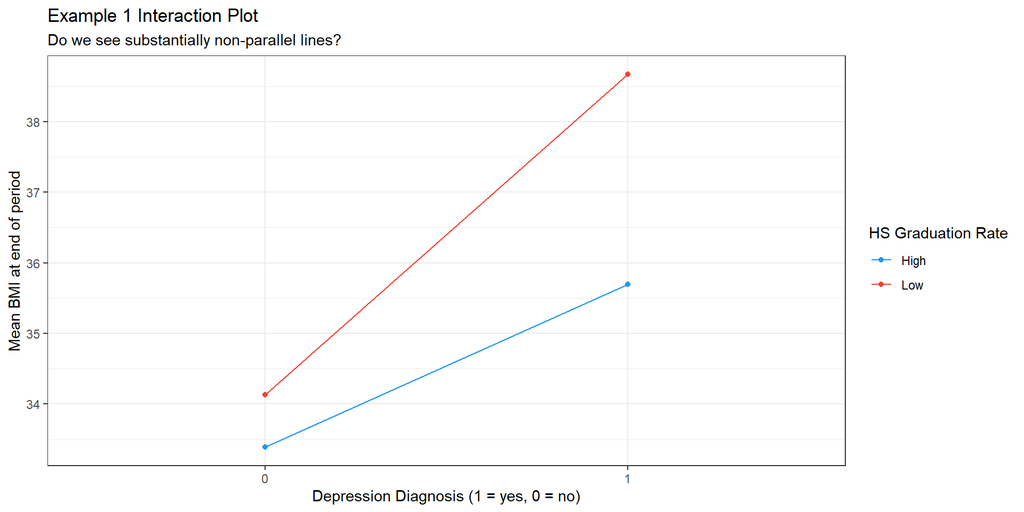

## Two-Way ANOVA with Interaction

Fit the linear model, including an interaction (`*`) between our factors.

```r
withint <- lm(bmi_end ~ dep_start * ed_start, data = dm18)

withint
```

```
Call:
lm(formula = bmi_end ~ dep_start * ed_start, data = dm18)

Coefficients:
           (Intercept)              dep_start1             ed_startLow
               33.3878                  2.3073                  0.7447
dep_start1:ed_startLow
                2.2284
```

## `withint` model equation?

$$bmi_{end} = 33.4 + 2.3 (dep_{start} = 1) \\
+ 0.7 (ed_{start} = Low) \\ + 2.2 (dep_{start} = 1) \times (ed_{start} = Low)$$

| `dep_start` | `ed_start` | Estimated `bmi_end` |
| --- | --- | --- |
| 0 | High | 33.4 |
| 0 | Low | 33.4 + 0.7 = 34.1 |
| 1 | High | 33.4 + 2.3 = 35.7 |
| 1 | Low | 33.4 + 2.3 + 0.7 + 2.2 = 38.6 |

## Effect of High vs. Low `ed_start`?

| Est. `bmi_end` | `ed_start` = High | `ed_start` = Low |
| --- | --- | --- |
| `dep_start` = 0 | 33.4 | 34.1 |
| `dep_start` = 1 | 35.7 | 38.6 |

- If `dep_start` = 0, High `ed_start` yields 33.4; Low yields 34.1, so High - Low difference in estimates is -0.7.
- If `dep_start` = 1, High `ed_start` yields 35.7; Low yields 38.6, so High - Low difference in estimates is -2.9.
- Estimated effect of `ed_start` **depends** on `dep_start`.

## Effect of `dep_start` = 1 vs. 0?

| Est. `bmi_end` | `ed_start` = High | `ed_start` = Low |
| --- | --- | --- |
| `dep_start` = 1 | 35.7 | 38.6 |
| `dep_start` = 0 | 33.4 | 34.1 |

- If `ed_start` is High, then `dep_start` = 1 yields 35.7, and 0 yields 33.4, so the difference in estimated `bmi_end` is 2.3.
- If `ed_start` is Low, then `dep_start` = 1 yields 38.6, and 0 yields 34.1, so the difference in estimated `bmi_end` is 4.5.
- Estimated effect of `dep_start` **depends** on `ed_start`.

## ANOVA table for `withint` model

```
Analysis of Variance Table

Response: bmi_end
                    Df Sum Sq Mean Sq F value    Pr(>F)
dep_start            1   1303 1302.59 17.1299 4.152e-05 ***
ed_start             1    280  280.48  3.6884   0.05541 .
dep_start:ed_start   1    133  133.25  1.7523   0.18625
Residuals          460  34979   76.04
---
Signif. codes:  0 '***' 0.001 '**' 0.01 '*' 0.05 '.' 0.1 ' ' 1
```

- Total SS = 1303 + 280 + 133 + 34979 = 36695
- % explained = (1303 + 280 + 133) / 36695 = 0.047, or 4.7%
- Is this a big improvement over the `mainfx` model?

## Checking model `withint`

```r
set.seed(202410291)
check_model(withint, check = c("pp_check", "qq"), detrend = FALSE)
```

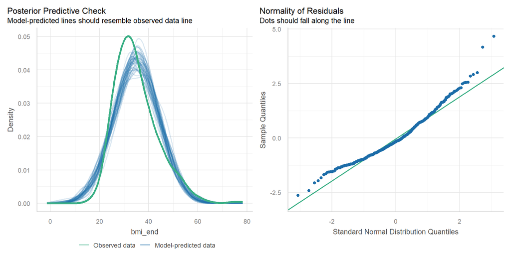

## Compare performance of our two models?

```r
compare_performance(mainfx, withint, rank = TRUE)
```

```
# Comparison of Model Performance Indices

Name    | Model |    R2 | R2 (adj.) |  RMSE | Sigma | AIC weights
-----------------------------------------------------------------
withint |    lm | 0.047 |     0.041 | 8.683 | 8.720 |       0.471
mainfx  |    lm | 0.043 |     0.039 | 8.699 | 8.727 |       0.529

Name    | AICc weights | BIC weights | Performance-Score
--------------------------------------------------------
withint |        0.465 |       0.101 |            57.14%
mainfx  |        0.535 |       0.899 |            42.86%
```

## Plot to compare performance indicators

```r
plot(compare_performance(mainfx, withint))
```

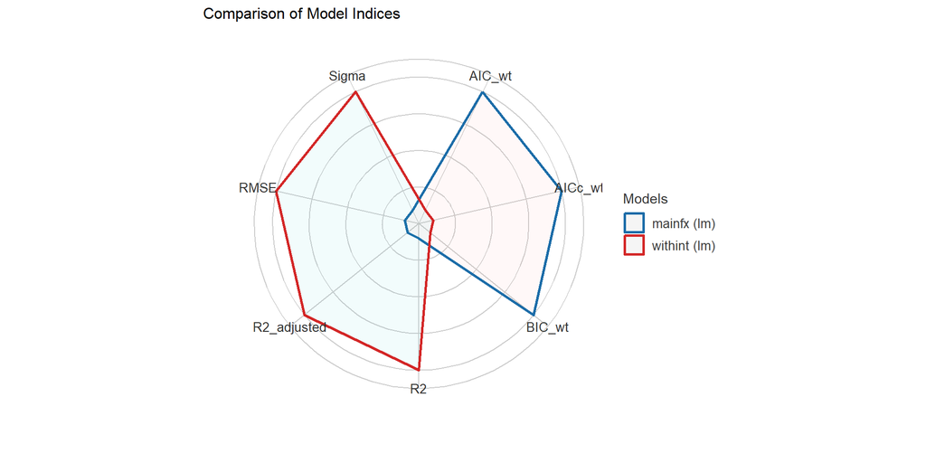

## Do we have a substantial interaction?

- Interaction plot shows slightly non-parallel lines.
- % of variation explained by the interaction term is about 0.4% of the variation in `bmi_end`, overall.
- p value for the interaction term is pretty large ($p$ = 0.19)
- Is there a substantial improvement in the fit with the interaction?
  - In-sample performance indices are split.

What do you think?

# Two-Factor Analysis of Variance: Example 2

## Example 2

Suppose that we now want to understand the impact on BMI at the end of the period, of:

- `insur_start` (Medicare, Commercial or Medicaid), and
- `ed_start` (Low or High)

and it’s possible that the impact of insurance on BMI may depend on the home neighborhood’s educational attainment, and vice versa (i.e. insurance and education may **interact**.)

## Build an interaction plot

Calculate and store group means.

```r
ex2_means <- dm18 |>
  group_by(insur_start, ed_start) |>
  summarize(mean_bmi = mean(bmi_end))

ex2_means
```

```
# A tibble: 6 × 3
# Groups:   insur_start [3]
  insur_start ed_start mean_bmi
  <fct>       <fct>       <dbl>
1 Medicare    High         33.6
2 Medicare    Low          34.1
3 Commercial  High         35.9
4 Commercial  Low          34.4
5 Medicaid    High         34.2
6 Medicaid    Low          38.2
```

## How strong is the interaction?

Now, we’ll plot these means, and look for a substantial interaction (non-parallel lines.)

```r
ggplot(ex2_means, aes(x = insur_start, y = mean_bmi)) +
  geom_line(aes(group = ed_start, color = ed_start)) +
  geom_point(aes(color = ed_start)) +
  scale_color_material() +
  labs(title = "Example 2 Interaction Plot",
       subtitle = "Do we see substantially non-parallel lines?",
       y = "Mean BMI at end of period",
       x = "Insurance at start of period",
       color = "HS Graduation Rate")
```

## How strong is the interaction?

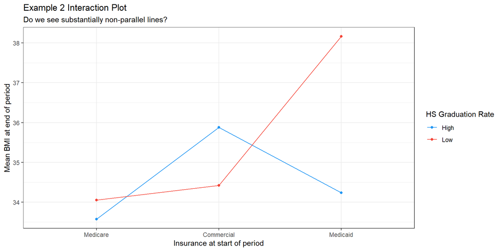

## Example 2: Two-Way ANOVA models

```r
mainfx2 <- lm(bmi_end ~ insur_start + ed_start, data = dm18)
withint2 <- lm(bmi_end ~ insur_start * ed_start, data = dm18)

compare_performance(mainfx2, withint2, rank = TRUE)
```

```
# Comparison of Model Performance Indices

Name     | Model |    R2 | R2 (adj.) |  RMSE | Sigma | AIC weights
------------------------------------------------------------------
withint2 |    lm | 0.037 |     0.027 | 8.727 | 8.784 |       0.758
mainfx2  |    lm | 0.024 |     0.018 | 8.786 | 8.824 |       0.242

Name     | AICc weights | BIC weights | Performance-Score
---------------------------------------------------------
withint2 |        0.747 |       0.048 |            85.71%
mainfx2  |        0.253 |       0.952 |            14.29%
```

## Plotting Performance Indices

```r
plot(compare_performance(mainfx2, withint2))
```

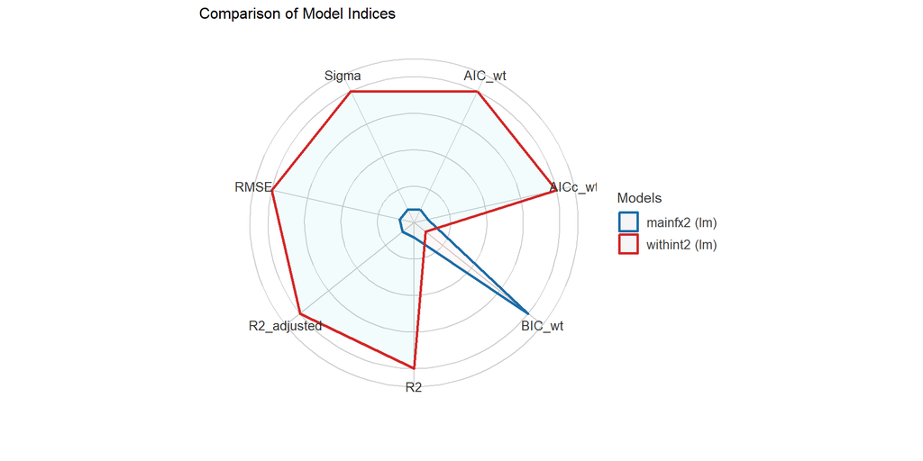

## Interpret `mainfx2` estimates?

```r
model_parameters(mainfx2, ci = 0.90, pretty_names = FALSE)
```

```
Parameter             | Coefficient |   SE |         90% CI | t(460) |      p
-----------------------------------------------------------------------------
(Intercept)           |       32.85 | 0.78 | [31.56, 34.13] |  42.02 | < .001
insur_startCommercial |        1.44 | 1.30 | [-0.70,  3.57] |   1.11 | 0.269
insur_startMedicaid   |        2.40 | 0.88 | [ 0.94,  3.85] |   2.72 | 0.007
ed_startLow           |        1.79 | 0.82 | [ 0.44,  3.15] |   2.18 | 0.030
```

$$bmi_{end} = 32.9 + 1.4 (Comm.) + 2.4 (Medicaid) + 1.8 (Low Ed.)$$

| Est. `bmi_end` | Medicare | Commercial | Medicaid |
| --- | --- | --- | --- |
| `ed_start` High | 32.9 | 34.3 | 35.3 |
| `ed_start` Low | 34.7 | 36.1 | 37.1 |

## Specify `withint2` equation?

```r
model_parameters(withint2, ci = 0.90, pretty_names = FALSE)
```

```
Parameter                         | Coefficient |   SE |         90% CI
-----------------------------------------------------------------------
(Intercept)                       |       33.57 | 0.95 | [32.01, 35.13]
insur_startCommercial             |        2.31 | 1.84 | [-0.72,  5.34]
insur_startMedicaid               |        0.66 | 1.26 | [-1.42,  2.74]
ed_startLow                       |        0.48 | 1.27 | [-1.61,  2.58]
insur_startCommercial:ed_startLow |       -1.94 | 2.58 | [-6.20,  2.32]
insur_startMedicaid:ed_startLow   |        3.44 | 1.76 | [ 0.55,  6.34]

Parameter                         | t(458) |      p
---------------------------------------------------
(Intercept)                       |  35.44 | < .001
insur_startCommercial             |   1.26 | 0.210
insur_startMedicaid               |   0.53 | 0.599
ed_startLow                       |   0.38 | 0.704
insur_startCommercial:ed_startLow |  -0.75 | 0.452
insur_startMedicaid:ed_startLow   |   1.96 | 0.051
```

## `withint2` model equation

$$bmi_{end} = 33.6 + 2.3 Commercial + 0.7 Medicaid + 0.5 (ed_{start} = Low) \\ - 1.9 Commercial \times (ed_{start} = Low) + 3.4 Medicaid \times (ed_{start} = Low)$$

| `insur_start` | `ed_start` | Estimated `bmi_end` |
| --- | --- | --- |
| Medicare | High | 33.6 |
| Commercial | High | 33.6 + 2.3 = 35.9 |
| Medicaid | High | 33.6 + 0.7 = 34.3 |
| Medicare | Low | 33.6 + 0.5 = 34.1 |
| Commercial | Low | 33.6 + 2.3 + 0.5 - 1.9 = 34.5 |
| Medicaid | Low | 33.6 + 0.7 + 0.5 + 3.4 = 38.2 |

## ANOVA table for main effects model

```r
anova(mainfx2)
```

```
Analysis of Variance Table

Response: bmi_end
             Df Sum Sq Mean Sq F value  Pr(>F)
insur_start   2    510  254.82  3.2727 0.03879 *
ed_start      1    369  369.45  4.7450 0.02989 *
Residuals   460  35817   77.86
---
Signif. codes:  0 '***' 0.001 '**' 0.01 '*' 0.05 '.' 0.1 ' ' 1
```

### % of Total SS explained by the two factors?

- Total SS = 510 + 369 + 35817 = 36696
- So % explained = (510 + 369) / 36696 = 0.024, or 2.4%

## ANOVA table for interaction model

```r
anova(withint2)
```

```
Analysis of Variance Table

Response: bmi_end
                      Df Sum Sq Mean Sq F value  Pr(>F)
insur_start            2    510  254.82  3.3029 0.03765 *
ed_start               1    369  369.45  4.7888 0.02915 *
insur_start:ed_start   2    482  240.88  3.1223 0.04500 *
Residuals            458  35335   77.15
---
Signif. codes:  0 '***' 0.001 '**' 0.01 '*' 0.05 '.' 0.1 ' ' 1
```

### % of Total SS explained by the model?

- Total SS = 510 + 369 + 482 + 35335 = 36696
- So % explained = (510 + 369 + 482) / 36696 = 0.037, or 3.7%

## Checking model `mainfx2`

```r
set.seed(202410292)
check_model(mainfx2, check = c("pp_check", "qq"), detrend = FALSE)
```

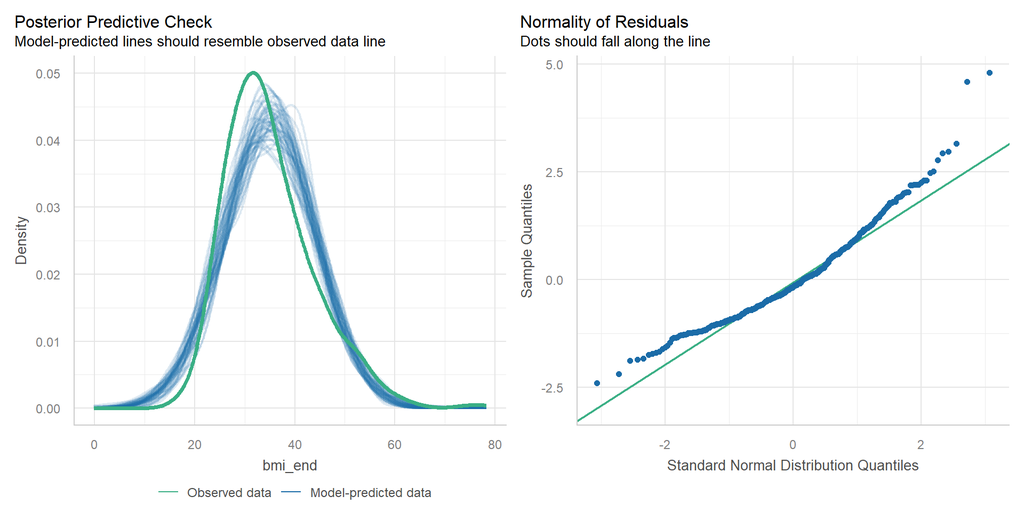

## Checking model `withint2`

```r
set.seed(202410293)
check_model(withint2, check = c("pp_check", "qq"), detrend = FALSE)
```

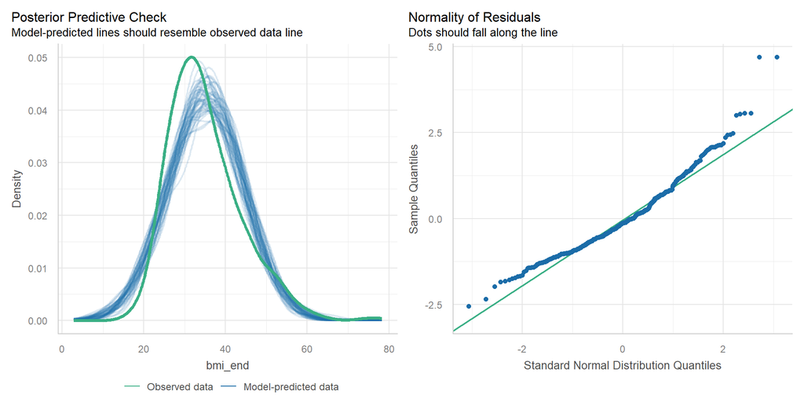

## Substantial interaction here?

- Interaction plot shows substantially non-parallel lines.
- Interaction term explains about 1.3% of the variation in `bmi_end`, overall.
- p value for the interaction term is fairly small ($p$ = 0.045)
- Substantial improvement in the fit with interaction?
  - 6/7 in-sample performance indices prefer interaction

What do you think?

# Add a covariate?

## What if we added a covariate?

```r
dm18a <- dm464 |>
  mutate(ed_start = factor(ifelse(nedlev_start > 78, "High", "Low")),
         dep_start = factor(depdiag_start)) |>
  mutate(bmi_c = center(bmi_start)) |>
  select(id_code, bmi_end, dep_start, ed_start, insur_start,
         bmi_c, bmi_start)

dm18a |> reframe(lovedist(bmi_start))
```

```
# A tibble: 1 × 10
      n  miss  mean    sd   med   mad   min   q25   q75   max
  <int> <int> <dbl> <dbl> <dbl> <dbl> <dbl> <dbl> <dbl> <dbl>
1   464     0  35.2  8.82  33.4  8.01  17.3  28.9  40.4  75.1
```

```r
dm18a |> reframe(lovedist(bmi_c))
```

```
# A tibble: 1 × 10
      n  miss     mean    sd   med   mad   min   q25   q75   max
  <int> <int>    <dbl> <dbl> <dbl> <dbl> <dbl> <dbl> <dbl> <dbl>
1   464     0 2.30e-15  8.82 -1.84  8.01 -17.9 -6.34  5.21  39.9
```

## Analysis of Covariance Model

```r
fit3 <- lm(bmi_end ~ bmi_c + dep_start * insur_start, data = dm18a)

anova(fit3)
```

```
Analysis of Variance Table

Response: bmi_end
                       Df Sum Sq Mean Sq   F value  Pr(>F)
bmi_c                   1  34213   34213 6413.8007 < 2e-16 ***
dep_start               1      8       8    1.4107 0.23556
insur_start             2     29      14    2.7165 0.06718 .
dep_start:insur_start   2      9       4    0.8135 0.44394
Residuals             457   2438       5
---
Signif. codes:  0 '***' 0.001 '**' 0.01 '*' 0.05 '.' 0.1 ' ' 1
```

## Proportion of Variation Explained

```r
eta_squared(fit3)
```

```
# Effect Size for ANOVA (Type I)

Parameter             | Eta2 (partial) |       95% CI
-----------------------------------------------------
bmi_c                 |           0.93 | [0.93, 1.00]
dep_start             |       3.08e-03 | [0.00, 1.00]
insur_start           |           0.01 | [0.00, 1.00]
dep_start:insur_start |       3.55e-03 | [0.00, 1.00]

- One-sided CIs: upper bound fixed at [1.00].
```

## Drop Interaction?

```r
fit4 <- lm(bmi_end ~ bmi_c + dep_start + insur_start, data = dm18a)

anova(fit4)
```

```
Analysis of Variance Table

Response: bmi_end
             Df Sum Sq Mean Sq   F value  Pr(>F)
bmi_c         1  34213   34213 6419.0169 < 2e-16 ***
dep_start     1      8       8    1.4119 0.23536
insur_start   2     29      14    2.7187 0.06702 .
Residuals   459   2446       5
---
Signif. codes:  0 '***' 0.001 '**' 0.01 '*' 0.05 '.' 0.1 ' ' 1
```

## Drop Depression?

```r
fit5 <- lm(bmi_end ~ bmi_c + insur_start, data = dm18a)

anova(fit5)
```

```
Analysis of Variance Table

Response: bmi_end
             Df Sum Sq Mean Sq   F value  Pr(>F)
bmi_c         1  34213   34213 6414.4440 < 2e-16 ***
insur_start   2     29      15    2.7587 0.06442 .
Residuals   460   2453       5
---
Signif. codes:  0 '***' 0.001 '**' 0.01 '*' 0.05 '.' 0.1 ' ' 1
```

## Compare fit3, fit4, fit5

```r
compare_performance(fit3, fit4, fit5, rank = TRUE)
```

```
# Comparison of Model Performance Indices

Name | Model |    R2 | R2 (adj.) |  RMSE | Sigma | AIC weights | AICc weights
-----------------------------------------------------------------------------
fit4 |    lm | 0.933 |     0.933 | 2.296 | 2.309 |       0.370 |        0.368
fit5 |    lm | 0.933 |     0.933 | 2.300 | 2.309 |       0.515 |        0.526
fit3 |    lm | 0.934 |     0.933 | 2.292 | 2.310 |       0.114 |        0.106

Name | BIC weights | Performance-Score
--------------------------------------
fit4 |       0.083 |            60.74%
fit5 |       0.916 |            46.38%
fit3 |    4.09e-04 |            28.57%
```

## Compare fit3, fit4, fit5

```r
plot(compare_performance(fit3, fit4, fit5))
```

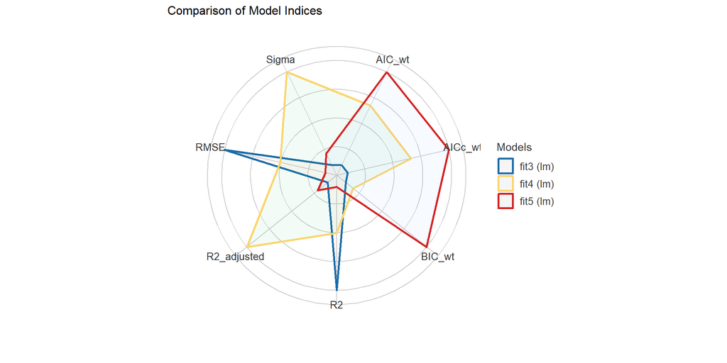

## Check Model `fit4` (1/3)

```r
check_model(fit4, check = c("pp_check", "qq"), detrend = FALSE)
```

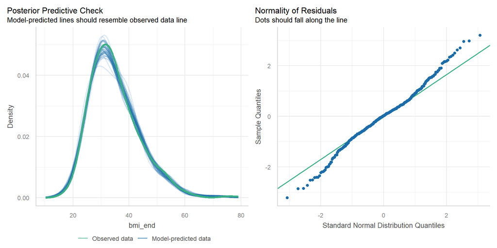

## Check Model `fit4` (2/3)

```r
check_model(fit4, check = c("linearity", "homogeneity"))
```

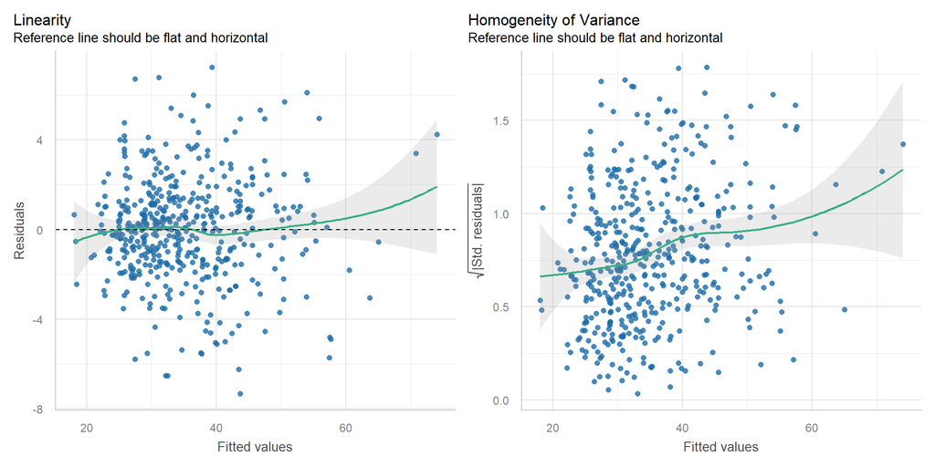

## Check Model `fit4` (3/3)

```r
check_model(fit4, check = c("outliers", "vif"))
```

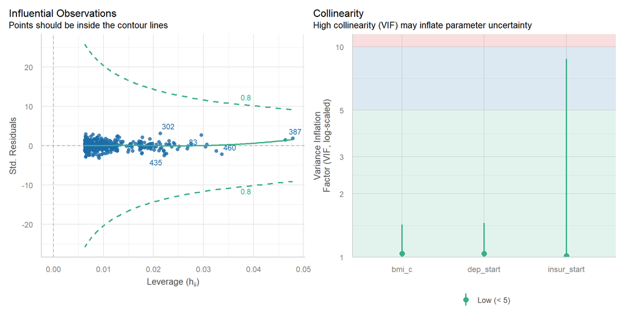